# PCA for low depth sequencing data

**Purpose.** Infer population structure from **genotype likelihoods**, without ever calling a genotype. At low depth a called genotype is often wrong, and the errors are not random — they depend on how deeply each individual was sequenced, which is exactly the kind of bias that can look like population structure.

**What you will do**

- run PCAngsd to estimate a covariance matrix straight from genotype likelihoods
- plot the principal components and compare them with admixture proportions
- see what happens when the individual allele frequencies are barely estimated
- let PCAngsd estimate admixture proportions from the PCA itself

**The data.** 435 individuals from the **1000 Genomes Project**, five populations:

| Code | Population | n |
| --- | --- | --- |
| ASW | African ancestry in the southwestern USA | 61 |
| CEU | Utah residents with northern/western European ancestry | 99 |
| CHB | Han Chinese in Beijing, China | 103 |
| MXL | Mexican ancestry in Los Angeles, USA | 64 |
| YRI | Yoruba in Ibadan, Nigeria | 108 |

The genotypes are **not** called: the file is a beagle-format table of genotype likelihoods, three numbers per individual per site.

**Before this** do MDS and PCA by hand, which builds the method this notebook runs with a tool.

## Setup

All the paths used by this exercise are set in the cell below.

[output not shown]

```
# the working directory was set in the first cell of the notebook
work_d <- readLines(path.expand("~/.pca_low_depth_human_workdir"))[1]
setwd(work_d)
getwd()
```

'/davidData/data/course/.nbrender_home/pca_low_depth_human'

# PCA for low depth sequencing using PCAngsd

In this exercise we will use PCAngsd to perform a PCA from **genotype likelihoods**, without ever calling a genotype. The data are five populations from the 1000 Genomes project, sequenced at low depth.

If you have not done the MDS and PCA by hand exercise, do that one first — it builds the method this notebook now runs with a tool.

Copy data to your newly created folder

```
# the files were linked into the folder in the setup cell
ls *.qopt *.pop.info *.beagle.gz
```

```
1000G5popsAdmixK3seed3.qopt  1000G5pops.inputgl.beagle.gz
1000G5popsAdmixK4seed9.qopt  1000G5pops.pop.info
```

Look inside the first lines in the population information file

```
head 1000G5pops.pop.info
```

```
YRI	NA18486
YRI	NA18488
YRI	NA18489
YRI	NA18498
YRI	NA18499
YRI	NA18501
YRI	NA18502
YRI	NA18504
YRI	NA18505
YRI	NA18507
```

See the number of individuals for each population from the sample file

```
# summarise the first column
cut -f1 1000G5pops.pop.info |  uniq -c
```

```
    108 YRI
     61 ASW
     99 CEU
     64 MXL
    103 CHB
```

**Question**

- How many individuals are there in each population, and how many populations in total?

Count the number of lines in the genotype likelihood file

```
zcat 1000G5pops.inputgl.beagle.gz | wc -l
```

```
102313
```

**Question**

- A beagle genotype likelihood file has one line per site plus a header, and three columns per individual. From the line count, how many sites are there?

```
from jupyterquiz import display_quiz

display_quiz("https://raw.githubusercontent.com/popgenDK/courses/main/current_exercises/pca/quiz/pcangsd.json")
```

## Run PCANGSD to perform PCA

First let's get a list of the options in PCAngsd

```
pcangsd -h
```

```
usage: pcangsd [-h] [--version] [-b FILE] [-p FILE-PREFIX] [-e INT] [-t INT]
               [-o OUTPUT] [--filter FILE] [--filter-sites FILE]
               [--geno-error FLOAT] [--maf FLOAT] [--maf-iter INT]
               [--maf-tole FLOAT] [--hwe FILE] [--hwe-tole FLOAT] [--iter INT]
               [--tole FLOAT] [--selection] [--snp-weights] [--pcadapt]
               [--selection-eig INT] [--inbreed-sites] [--inbreed-samples]
               [--inbreed-iter INT] [--inbreed-tole FLOAT] [--post]
               [--post-inbreed] [--geno FLOAT] [--geno-inbreed FLOAT]
               [--admix] [--admix-K INT] [--admix-iter INT]
               [--admix-tole FLOAT] [--admix-batch INT] [--admix-alpha FLOAT]
               [--admix-seed INT] [--admix-auto FLOAT] [--admix-depth INT]
               [--tree] [--tree-samples FILE] [--maf-save] [--pi-save]
               [--dosage-save] [--sites-save]

options:
  -h, --help            show this help message and exit
  --version             show program's version number and exit
  -b FILE, --beagle FILE
                        Filepath to genotype likelihoods in gzipped Beagle
                        format from ANGSD
  -p FILE-PREFIX, --plink FILE-PREFIX
                        Prefix PLINK files (.bed, .bim, .fam)
  -e INT, --eig INT     Manual selection of number of eigenvectors in
                        modelling
  -t INT, --threads INT
                        Number of threads (1)
  -o OUTPUT, --out OUTPUT
                        Prefix for output files
  --filter FILE         Input file of vector for filtering samples
  --filter-sites FILE   Input file of vector for filtering sites
  --geno-error FLOAT    Incorporate errors into genotypes (0.0)
  --maf FLOAT           Minimum minor allele frequency threshold (0.05)
  --maf-iter INT        Maximum iterations for minor allele frequencies
                        estimation - EM (500)
  --maf-tole FLOAT      Tolerance for minor allele frequencies estimation
                        update - EM (1e-6)
  --hwe FILE            Input file of LRTs from HWE test for site filtering
  --hwe-tole FLOAT      Tolerance for HWE filtering of sites (1e-6)
  --iter INT            Maximum iterations for estimation of individual allele
                        frequencies (100)
```

[output cut: 24 more lines]

```
  --admix-tole FLOAT    Tolerance for admixture estimations - NMF (1e-5)
  --admix-batch INT     Number of mini-batches in stochastic admixture
                        estimations - NMF (10)
  --admix-alpha FLOAT   Alpha value for regularization in admixture
                        estimations - NMF (0.0)
  --admix-seed INT      Random seed used in admixture estimations - NMF (0)
  --admix-auto FLOAT    Enable automatic search for alpha by giving soft upper
                        search bound
  --admix-depth INT     Depth in automatic search of alpha (7)
  --tree                Construct NJ tree from covariance matrix
  --tree-samples FILE   List of sample names to create beautiful tree
  --maf-save            Save population allele frequencies
  --pi-save             Save individual allele frequencies
  --dosage-save         Save genotype dosages
  --sites-save          Save boolean vector of used sites
```

Run PCANGSD on your genotype likelihood data using 5 CPU threads (will take ~1min)

```
pcangsd -b 1000G5pops.inputgl.beagle.gz -o PCANGSD1000G -t 5
```

```
------------------------------------
PCAngsd v1.36.4
Jonas Meisner and Anders Albrechtsen
Using 5 thread(s)
------------------------------------

Parsing Beagle file.
Loaded 102312 sites and 435 samples.
Estimating minor allele frequencies.
EM (MAF) converged at iteration: 5
Number of sites after MAF filtering (0.05): 102312

Estimating covariance matrix.
Using 3 principal components (MAP test).
Individual allele frequencies estimated (1).
Individual allele frequencies estimated (2).	RMSE=0.0029545
Individual allele frequencies estimated (3).	RMSE=0.0007774
Individual allele frequencies estimated (4).	RMSE=0.0002334
Individual allele frequencies estimated (5).	RMSE=0.0000762
Individual allele frequencies estimated (6).	RMSE=0.0000261
Individual allele frequencies estimated (7).	RMSE=0.0000093
PCAngsd converged.
Saved covariance matrix as PCANGSD1000G.cov

Total elapsed time: 0m20s
```

**Question**

- PCAngsd estimated a covariance matrix rather than calling genotypes. Why is that the right thing to do at low depth?

The program estimates the covariance matrix that can then be used for PCA. Look at the output from the program

- How many significant PCA was used by PCAngsd (see MAP test in output)?

Plot the results in R

```
# Read covariance matrix estimated by PCAngsd
C <- as.matrix(read.table("PCANGSD1000G.cov"))

# Read population labels for each individuals
pop<-read.table("1000G5pops.pop.info",stringsAsFactors=T)

# Estimate the eigenvectors (principal components) from the covariance matrix
e <- eigen(C)
plot(e$vectors[,c(1,2)],col=pop[,1],xlab="PC1",ylab="PC2")
legend("left",fill=1:5,levels(pop[,1]))


# Estimate the eigenvectors (principal components) from the covariance matrix
e <- eigen(C)
plot(e$vectors[,c(1,3)],col=pop[,1],xlab="PC1",ylab="PC3")
legend("left",fill=1:5,levels(pop[,1]))
```

[figure not shown]

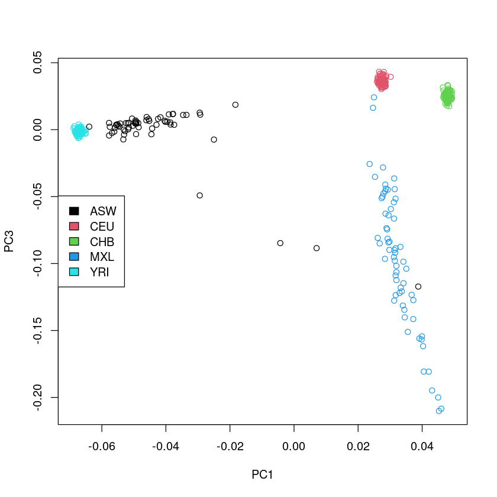

**Questions**

- Which populations sit close together, and which are far apart?
- Does PC1 separate the same populations as PC2?

Compare with the estimate admixture proportions (a NGSadmix analysis)

```
source("https://raw.githubusercontent.com/GenisGE/evalAdmix/refs/heads/master/visFuns.R")

par(mfrow=2:1)
## read and plot the output from NGSadmix from the Tuesday's exercises
pop<-read.table("1000G5pops.pop.info",as.is=T)
q<-read.table("1000G5popsAdmixK3seed3.qopt")
# sort indiivduals by population and within populaoitn by admixture proportion
ord<-orderInds(pop = pop[,1], q=q)

#plot
barplot(t(q)[,ord],col=2:10,space=0,border=NA,xlab="Individuals",
        ylab="Admixture proportions",main="K=3")
text(sort(tapply(1:nrow(pop),pop[ord,1],mean)),-0.05,
     unique(pop[ord,1]),xpd=T) # add population labels
abline(v=cumsum(sapply(unique(pop[ord,1]),
                       function(x){sum(pop[ord,1]==x)})),col=1,lwd=1.2)

## read for K=4
pop<-read.table("1000G5pops.pop.info",as.is=T)
q<-read.table("1000G5popsAdmixK4seed9.qopt")
plot
barplot(t(q)[,ord],col=2:10,space=0,border=NA,xlab="Individuals",
        ylab="Admixture proportions",main="K=4")
text(sort(tapply(1:nrow(pop),pop[ord,1],mean)),-0.05,unique(pop[ord,1]),
     xpd=T) # add population labels
abline(v=cumsum(sapply(unique(pop[ord,1]),
                       function(x){sum(pop[ord,1]==x)})),col=1,lwd=1.2)
```

```
function (x, y, ...)
UseMethod("plot")
```

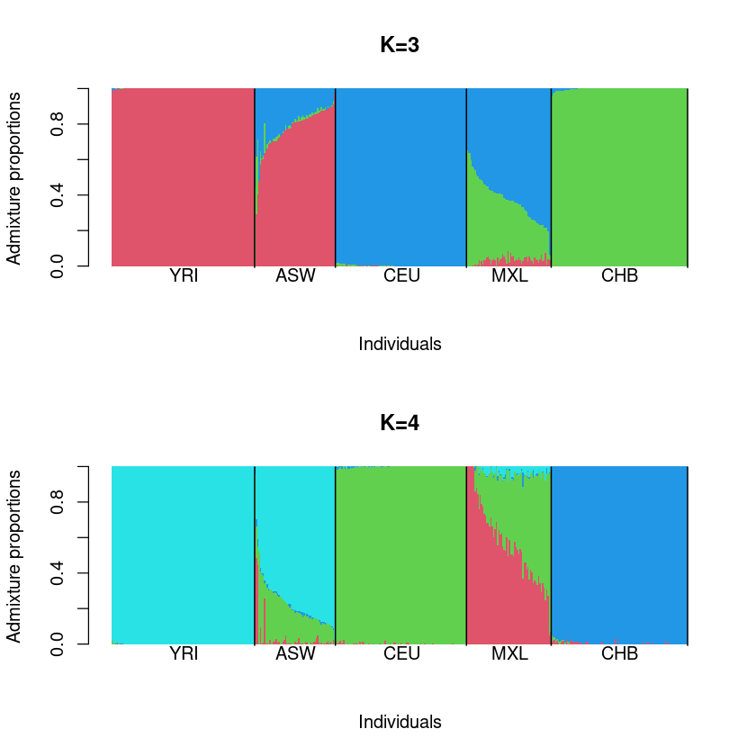

**Questions**

- In the PCA plot can you identify the Mexicans with only European ancestry?
- What about the ones with mostly Native American ancestry?
- What does the PCA tell you that the admixture proportions do not?

### Run the cell below to take the quiz

```
from jupyterquiz import display_quiz

display_quiz("https://raw.githubusercontent.com/popgenDK/courses/main/current_exercises/pca/quiz/pcangsd.json")
```

- In the PCA plot can you identify the Mexicans with only European ancestry?
- What about the African American with East Asian ancestry?
- Based on the PCA would you have reached the same conclusion as the admixture proportions?

## What if we dont use many iterations in PCAngnd

Try the same analysis but with only one iteration in the algorithm so that the result has not converged. Then we do not fully take the population structure into account when filling in the missing information

```
pcangsd -b 1000G5pops.inputgl.beagle.gz -o PCANGSD1000G_iter0 -t 5 --iter 1 -e 1
```

```
------------------------------------
PCAngsd v1.36.4
Jonas Meisner and Anders Albrechtsen
Using 5 thread(s)
------------------------------------

Parsing Beagle file.
Loaded 102312 sites and 435 samples.
Estimating minor allele frequencies.
EM (MAF) converged at iteration: 5
Number of sites after MAF filtering (0.05): 102312

Estimating covariance matrix.
Using 1 principal components (manually selected).
Individual allele frequencies estimated (1).
Individual allele frequencies estimated (2).	RMSE=0.0028839
PCAngsd did not converge!
Saved covariance matrix as PCANGSD1000G_iter0.cov

Total elapsed time: 0m18s
```

**Question**

- This run used `--iter 1 -e 1`, so the individual allele frequencies are barely estimated. What do you expect to change?

wait for the analysis to finish and then plot the results in R using the code below

```
# Read covariance matrix estimated by PCAngsd
C <- as.matrix(read.table("PCANGSD1000G_iter0.cov"))

# Read population labels for each individuals
pop<-read.table("1000G5pops.pop.info",stringsAsFactors=T)

# Estimate the eigenvectors (Principal components) from the covariance matrix
e <- eigen(C)
plot(e$vectors[,1:2],col=pop[,1],xlab="PC1",ylab="PC2")
legend("top",fill=1:5,levels(pop[,1]))
```

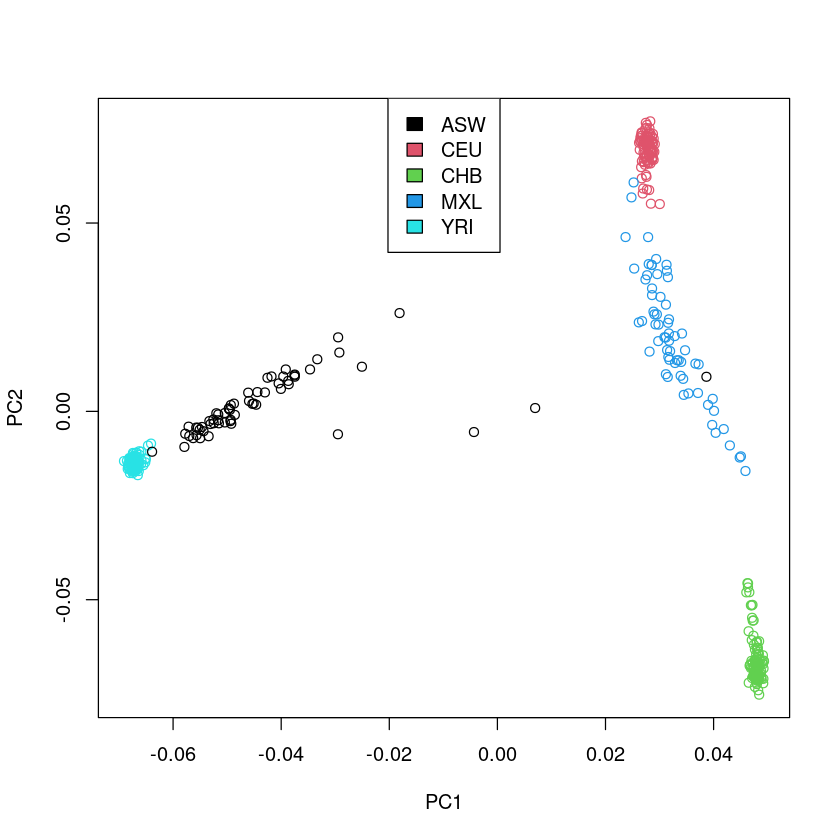

**Questions**

- Do you see any difference from the first plot?
- Would any of your conclusions change?
- Do you see any difference?
- Would any of your conclusions change? (compared to the previous PCA plot)

## Converting a PCA into admixture proportions

```
pcangsd -b 1000G5pops.inputgl.beagle.gz -o PCANGSD1000G -t 5 --admix --admix-alpha 50
```

```
------------------------------------
PCAngsd v1.36.4
Jonas Meisner and Anders Albrechtsen
Using 5 thread(s)
------------------------------------

Parsing Beagle file.
Loaded 102312 sites and 435 samples.
Estimating minor allele frequencies.
EM (MAF) converged at iteration: 5
Number of sites after MAF filtering (0.05): 102312

Estimating covariance matrix.
Using 3 principal components (MAP test).
Individual allele frequencies estimated (1).
Individual allele frequencies estimated (2).	RMSE=0.0029545
Individual allele frequencies estimated (3).	RMSE=0.0007774
Individual allele frequencies estimated (4).	RMSE=0.0002334
Individual allele frequencies estimated (5).	RMSE=0.0000762
Individual allele frequencies estimated (6).	RMSE=0.0000261
Individual allele frequencies estimated (7).	RMSE=0.0000093
PCAngsd converged.
Saved covariance matrix as PCANGSD1000G.cov

Estimating admixture proportions using NMF (CSG-MU).
K=4, Alpha=50.0, Batches=10, Seed=0
CSG-MU (1).	RMSE=0.258245868
CSG-MU (2).	RMSE=0.206069573
CSG-MU (3).	RMSE=0.025059432
CSG-MU (4).	RMSE=0.011713654
CSG-MU (5).	RMSE=0.003445602
CSG-MU (6).	RMSE=0.002218479
CSG-MU (7).	RMSE=0.001974765
CSG-MU (8).	RMSE=0.032458021
CSG-MU (9).	RMSE=0.050058253
CSG-MU (10).	RMSE=0.027488853
CSG-MU (11).	RMSE=0.016300201
CSG-MU (12).	RMSE=0.013768710
CSG-MU (13).	RMSE=0.020010797
CSG-MU (14).	RMSE=0.026992867
```

[output cut: 16 more lines]

```
CSG-MU (31).	RMSE=0.000126930
CSG-MU (32).	RMSE=0.000076260
CSG-MU (33).	RMSE=0.000049823
CSG-MU (34).	RMSE=0.000033125
CSG-MU (35).	RMSE=0.000021957
CSG-MU (36).	RMSE=0.000015631
CSG-MU (37).	RMSE=0.000011644
CSG-MU (38).	RMSE=0.000008968
Converged.
Frobenius error: 32.42795
Log-likelihood: -34669248.03777
Saved admixture proportions as PCANGSD1000G.admix.4.Q
Saved ancestral allele frequencies proportions as PCANGSD1000G.admix.4.P

Total elapsed time: 0m23s
```

**Question**

- `--admix` makes PCAngsd estimate admixture proportions from the PCA itself. How does that differ from running NGSadmix?

Plot the results in R

```
# Read the admixture proportions estimated from the PCA
q<-read.table("PCANGSD1000G.admix.4.Q")

# Read population labels for each individuals
pop<-read.table("1000G5pops.pop.info",stringsAsFactors=T)

## Order according to population
ord<-orderInds(pop = pop[,1], q=q) # sort indiivduals by population and within populaoitn by admixture proportion

#plot
barplot(t(q)[,ord],col=2:10,space=0,border=NA,xlab="Individuals",
        ylab="Admixture proportions")
text(sort(tapply(1:nrow(pop),pop[ord,1],mean)),-0.05,
     unique(pop[ord,1]),xpd=T) # add population labels
abline(v=cumsum(sapply(unique(pop[ord,1]),
                       function(x){sum(pop[ord,1]==x)})),col=1,lwd=1.2)
```

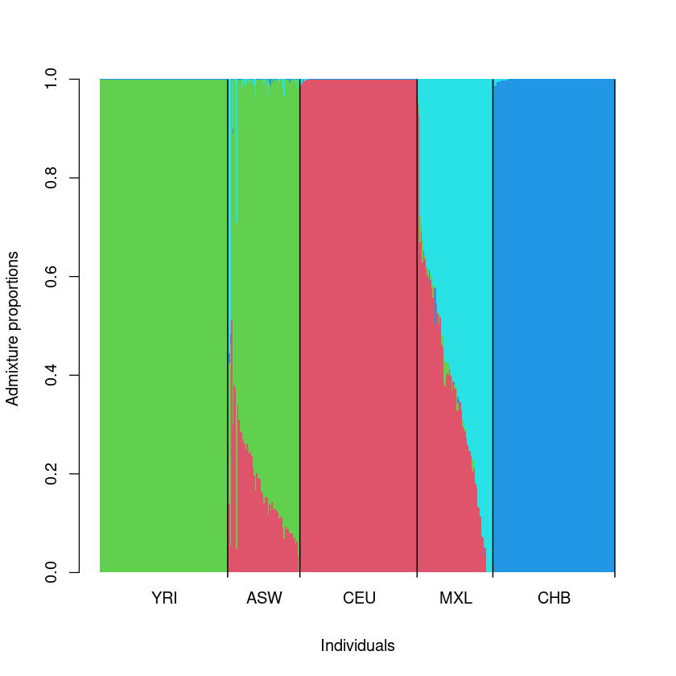

**Question**

- How does this compare with the NGSadmix result you plotted earlier?
- how does this compare to the results from an admixture proportion analysis (the NGSadmix analysis above)?